# Machine Learning Project

Marius Nicolescu

19 octombrie 2015

## Executive summary

Using more types devices it is now possible to collect a large amount of data about personal activity. Data was collected from 6 participants, from accelerometers mounted on the arm, belly on the belt, forearm, arm, and dumbbell.

Our goal is to develop a machine learning to predict the type of movement that do a participant. For this we will use three model.

The first and second will be based RandomForest (but using different packages of R caret and RandomForest) and the third model predict wiht tree.

Finally we compare the performance of the three models (the speed and accuracy)

## Load data

The data for this assignment comes from (http://groupware.les.inf.puc-rio.br/har) and contains information from accelerometers.

The data are split into a training group this have 19.622 rows, 160 columns and test set( for predict) 20 rows and 160 columns.

Data from these sensors are associated with the following five activities: Sitting, Sitting down, Standing, Standing up, Walking. The outcome used for this is the ???classe??? variable.

```r
library(caret)
library(randomForest)
```

```r
library(rpart)
library(rpart.plot)
##Load data from file
setwd("~/R/predict")
datatrain0<-read.csv("pml-training (2).csv", na.strings = c(NA,"","DIV/0!"))
datatest<-read.csv("pml-testing (1).csv")
```

## Remove the columns not needed.

```r
## Cleaning data
datatrain1<-datatrain0[,colSums(is.na(datatrain0))==0]
datatest1<-datatest[,colSums(is.na(datatest))==0]
datatrain1<-datatrain1[,-(1:6)]
```

Now dimension of traing set is:

```
## [1] 19622    54
```

## Create the cross validation trainset

The training data is split 70:30 for cross validation. 70% is used for training and 30% is used for validation.

```r
#Preproces trainig test
intrain<-createDataPartition(y=datatrain1$classe,p=0.7,list=FALSE)
training2<-datatrain1[intrain,]
testing2<-datatrain1[-intrain,]
```

## Train Model

I tried to use that training and regression model multiiniara, but the results were weak (acurracy = 0.34). RandomForest method is more recommended.

```r
# Matrix for record performance
performance<-matrix(data=NA,nrow = 2,ncol=3)
colnames(performance)<-c("RandomForest(RandomForest)","RandomForest(Caret)","Tree(rpart)")
row.names(performance)<-c("Time/Speed", "Accuracy")

## Model1 Random Forest with package randomForest
procesortime<-proc.time()
model1<-randomForest(classe~.,data=training2,methods="class")
t<-proc.time()-procesortime
performance[1,1]<-t[1]
#summary(model1)
prediction1<-predict(model1,testing2,type="class")
Matrix1<-confusionMatrix(prediction1,testing2$classe)
performance[2,1]<-Matrix1$overall[1]
# Model 2 Random Forest with package caret
procesortime<-proc.time()
model2<- train(classe~., method="rf", data=training2,
                 trControl=trainControl(method='cv',5), ntree=250)
t<-proc.time()-procesortime
performance[1,2]<-t[1]
predict2<-predict(model2, testing2)
Matrix2<-confusionMatrix(predict2,testing2$classe)
performance[2,2]<-Matrix2$overall[1]
 #Model 3 Tree  package rpart
procesortime<-proc.time()
treeView<-rpart(classe~., data=training2 , method="class")
t<-proc.time()-procesortime
performance[1,3]<-t[1]
predict3<-predict(treeView, testing2,type="class")
Matrix3<-confusionMatrix(predict3,testing2$classe)
performance[2,3]<-Matrix3$overall[1]
```

## First model

With many variables dependent on each other, Random Forest is a recommended model Fist model use Random Forest packet Type of random forest: classification, Number of trees: 500, each split: 7

```
## Confusion Matrix and Statistics
##
##           Reference
## Prediction    A    B    C    D    E
##          A 1674    1    0    0    0
##          B    0 1137    6    0    0
##          C    0    1 1020   11    0
##          D    0    0    0  953    3
##          E    0    0    0    0 1079
##
## Overall Statistics
##
##                Accuracy : 0.9963
##                  95% CI : (0.9943, 0.9977)
##     No Information Rate : 0.2845
##     P-Value [Acc > NIR] : < 2.2e-16
##
##                   Kappa : 0.9953
##  Mcnemar's Test P-Value : NA
##
## Statistics by Class:
##
##                      Class: A Class: B Class: C Class: D Class: E
## Sensitivity            1.0000   0.9982   0.9942   0.9886   0.9972
## Specificity            0.9998   0.9987   0.9975   0.9994   1.0000
## Pos Pred Value         0.9994   0.9948   0.9884   0.9969   1.0000
## Neg Pred Value         1.0000   0.9996   0.9988   0.9978   0.9994
## Prevalence             0.2845   0.1935   0.1743   0.1638   0.1839
## Detection Rate         0.2845   0.1932   0.1733   0.1619   0.1833
## Detection Prevalence   0.2846   0.1942   0.1754   0.1624   0.1833
## Balanced Accuracy      0.9999   0.9985   0.9958   0.9940   0.9986
```

## Second Model

Random Forest packet Caret

```
## Confusion Matrix and Statistics
##
##           Reference
## Prediction    A    B    C    D    E
##          A 1674    3    0    0    0
##          B    0 1135    1    0    0
##          C    0    1 1025    8    0
##          D    0    0    0  956    5
##          E    0    0    0    0 1077
##
## Overall Statistics
##
##                Accuracy : 0.9969
##                  95% CI : (0.9952, 0.9982)
##     No Information Rate : 0.2845
##     P-Value [Acc > NIR] : < 2.2e-16
##
##                   Kappa : 0.9961
##  Mcnemar's Test P-Value : NA
##
## Statistics by Class:
##
##                      Class: A Class: B Class: C Class: D Class: E
## Sensitivity            1.0000   0.9965   0.9990   0.9917   0.9954
## Specificity            0.9993   0.9998   0.9981   0.9990   1.0000
## Pos Pred Value         0.9982   0.9991   0.9913   0.9948   1.0000
## Neg Pred Value         1.0000   0.9992   0.9998   0.9984   0.9990
## Prevalence             0.2845   0.1935   0.1743   0.1638   0.1839
## Detection Rate         0.2845   0.1929   0.1742   0.1624   0.1830
## Detection Prevalence   0.2850   0.1930   0.1757   0.1633   0.1830
## Balanced Accuracy      0.9996   0.9981   0.9986   0.9953   0.9977
```

## Third Model

Predict with tree

```
## Confusion Matrix and Statistics
##
##           Reference
## Prediction    A    B    C    D    E
##          A 1400   72   13   18   42
##          B  169  870   58   77  162
##          C    8   69  810  205   59
##          D   91   78  141  610   98
##          E    6   50    4   54  721
##
## Overall Statistics
##
##                Accuracy : 0.7495
##                  95% CI : (0.7383, 0.7606)
##     No Information Rate : 0.2845
##     P-Value [Acc > NIR] : < 2.2e-16
##
##                   Kappa : 0.6841
##  Mcnemar's Test P-Value : < 2.2e-16
##
## Statistics by Class:
##
##                      Class: A Class: B Class: C Class: D Class: E
## Sensitivity            0.8363   0.7638   0.7895   0.6328   0.6664
## Specificity            0.9656   0.9018   0.9298   0.9171   0.9763
## Pos Pred Value         0.9061   0.6512   0.7037   0.5992   0.8635
## Neg Pred Value         0.9369   0.9409   0.9544   0.9273   0.9285
## Prevalence             0.2845   0.1935   0.1743   0.1638   0.1839
## Detection Rate         0.2379   0.1478   0.1376   0.1037   0.1225
## Detection Prevalence   0.2625   0.2270   0.1956   0.1730   0.1419
## Balanced Accuracy      0.9009   0.8328   0.8596   0.7749   0.8213
```

## Performance

Performance for three models are:

```
##            RandomForest(RandomForest) RandomForest(Caret) Tree(rpart)
## Time/Speed                 40.0300000         344.2800000   3.0000000
## Accuracy                    0.9962617           0.9969414   0.7495327
```

View Tree

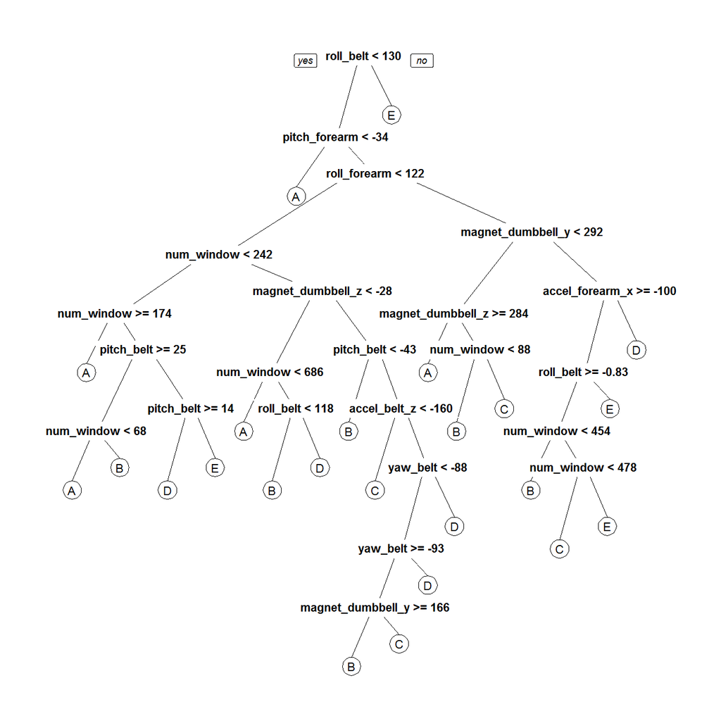

```r
prp(treeView)
```